# TPW Data Exploration

Guy Lomax

2023-03-13

# Load and pre-process data

Original data were in the form of a nested layer, with each point (sampling event) accompanied by a nested table of 20 rows, one for every 5 m along the 100 m N-S transect. Data were thus extracted as two separate files: a shapefile containing 7,273 rows (one per sampling event) and a csv containing 130,102 rows (20 per sampling event, with some records having more or fewer).

| globalid | deviceid | start | end | village | monitor | dateTime | plotIDng | plotIDmd | plotIDmn | plotIDos | plotIDvv | plotIDba | plotIDes | plotIDlo | plotIDmu | plotIDot | plotIDlm | plotIDlg | plotIDod | plotIDmc | plotIDmj | plotIDnt | plotIDse | plotIDer | plotIDir | plotIDls | village_pl | plotburned | plotgrazed | … |
| --- | --- | --- | --- | --- | --- | --- | --- | --- | --- | --- | --- | --- | --- | --- | --- | --- | --- | --- | --- | --- | --- | --- | --- | --- | --- | --- | --- | --- | --- | --- |
| {f5163e49-c64a-467e-a81d-ba0689a11d38} | 5f44c57fff3146e5a15264b17cc6d756 | 2019-08-27 | 2019-08-27 | Loibor_Siret | OloshiroSaidimu | 2019-08-27 | NA | NA | NA | NA | NA | NA | NA | NA | NA | NA | NA | NA | NA | NA | NA | NA | NA | NA | NA | Ngung_Ronjo | Loibor_Siret, Ngung_Ronjo | No | Yes | … |
| {81a7b02f-df20-494e-955d-050009e30f5b} | 5f44c57fff3146e5a15264b17cc6d756 | 2019-08-27 | 2019-08-27 | Loibor_Siret | OloshiroSaidimu | 2019-08-27 | NA | NA | NA | NA | NA | NA | NA | NA | NA | NA | NA | NA | NA | NA | NA | NA | NA | NA | NA | Oldonyo_Nape | Loibor_Siret, Oldonyo_Nape | No | Yes | … |
| {126c4f84-26e2-45e9-a6b8-f493da16eaf6} | 5f44c57fff3146e5a15264b17cc6d756 | 2019-08-27 | 2019-08-27 | Loibor_Siret | OloshiroSaidimu | 2019-08-27 | NA | NA | NA | NA | NA | NA | NA | NA | NA | NA | NA | NA | NA | NA | NA | NA | NA | NA | NA | Oldule | Loibor_Siret, Oldule | No | Yes | … |
| {479f37c8-7e19-4b0b-8a94-b432222a2a4f} | 5f44c57fff3146e5a15264b17cc6d756 | 2019-08-27 | 2019-08-27 | Loibor_Siret | OloshiroSaidimu | 2019-08-27 | NA | NA | NA | NA | NA | NA | NA | NA | NA | NA | NA | NA | NA | NA | NA | NA | NA | NA | NA | Pario_la_Laiboni | Loibor_Siret, Pario_la_Laiboni | No | Yes | … |
| {14459bd4-6d20-44b5-b192-0822b1ece0f9} | 5f44c57fff3146e5a15264b17cc6d756 | 2019-08-27 | 2019-08-27 | Loibor_Siret | OloshiroSaidimu | 2019-08-27 | NA | NA | NA | NA | NA | NA | NA | NA | NA | NA | NA | NA | NA | NA | NA | NA | NA | NA | NA | Oljasika | Loibor_Siret, Oljasika | Yes | Yes | … |
| {027128c6-9e57-4f21-8938-43a990958c1d} | 5f44c57fff3146e5a15264b17cc6d756 | 2019-08-27 | 2019-08-27 | Loibor_Siret | OloshiroSaidimu | 2019-08-27 | NA | NA | NA | NA | NA | NA | NA | NA | NA | NA | NA | NA | NA | NA | NA | NA | NA | NA | NA | Ngahari | Loibor_Siret, Ngahari | Yes | No | … |

| OID_ | globalid | village_plot | date | sampleID | markbare | markbasal | invasives | invasives_other | Argemone_spp_invasives | Atripoemoea_hyocyamoides_invasives | Bidens_schimperi_invasives | Brillantaisia_lamium_invasives | Caesalpinia_decapetala_invasives | Datura_stramonium_invasives | Gutenbergia_cordifolia_invasives | Hibiscus_spp_invasives | Ipomoea_hildebrantii_invasives | Oxygonum_sinuatum_invasives | Parthenium_hysterophorus_invasives | Solanum_incanum_invasives | Tribulus_terrestris_invasives | Xanthium_strumarium_invasives | Clutia_abyssinica_invasives | Tagetes_minuta_invasives | Eleusine_jaegeri_invasives | Senna_siamea_invasives | grassheight | parentglobalid | CreationDate | … |
| --- | --- | --- | --- | --- | --- | --- | --- | --- | --- | --- | --- | --- | --- | --- | --- | --- | --- | --- | --- | --- | --- | --- | --- | --- | --- | --- | --- | --- | --- | --- |
| 1 | NA | Loibor_Siret, Ngung_Ronjo | 27/08/2019 09:00:00 | 5 | 0 | 5 | None | NA | 0 | 0 | 0 | 0 | 0 | 0 | 0 | 0 | 0 | 0 | 0 | 0 | 0 | 0 | 0 | 0 | 0 | 0 | 60 | {F5163E49-C64A-467E-A81D-BA0689A11D38} | 04/06/2021 09:17:17 | … |
| 2 | NA | Loibor_Siret, Ngung_Ronjo | 27/08/2019 09:00:00 | 10 | 0 | 5 | None | NA | 0 | 0 | 0 | 0 | 0 | 0 | 0 | 0 | 0 | 0 | 0 | 0 | 0 | 0 | 0 | 0 | 0 | 0 | 50 | {F5163E49-C64A-467E-A81D-BA0689A11D38} | 04/06/2021 09:17:17 | … |
| 3 | NA | Loibor_Siret, Ngung_Ronjo | 27/08/2019 09:00:00 | 15 | 1 | 4 | None | NA | 0 | 0 | 0 | 0 | 0 | 0 | 0 | 0 | 0 | 0 | 0 | 0 | 0 | 0 | 0 | 0 | 0 | 0 | 50 | {F5163E49-C64A-467E-A81D-BA0689A11D38} | 04/06/2021 09:17:17 | … |
| 4 | NA | Loibor_Siret, Ngung_Ronjo | 27/08/2019 09:00:00 | 20 | 0 | 5 | None | NA | 0 | 0 | 0 | 0 | 0 | 0 | 0 | 0 | 0 | 0 | 0 | 0 | 0 | 0 | 0 | 0 | 0 | 0 | 60 | {F5163E49-C64A-467E-A81D-BA0689A11D38} | 04/06/2021 09:17:17 | … |
| 5 | NA | Loibor_Siret, Ngung_Ronjo | 27/08/2019 09:00:00 | 25 | 0 | 5 | None | NA | 0 | 0 | 0 | 0 | 0 | 0 | 0 | 0 | 0 | 0 | 0 | 0 | 0 | 0 | 0 | 0 | 0 | 0 | 67 | {F5163E49-C64A-467E-A81D-BA0689A11D38} | 04/06/2021 09:17:17 | … |
| 6 | NA | Loibor_Siret, Ngung_Ronjo | 27/08/2019 09:00:00 | 30 | 0 | 5 | None | NA | 0 | 0 | 0 | 0 | 0 | 0 | 0 | 0 | 0 | 0 | 0 | 0 | 0 | 0 | 0 | 0 | 0 | 0 | 62 | {F5163E49-C64A-467E-A81D-BA0689A11D38} | 04/06/2021 09:17:17 | … |

Join points to table and condense transect data into summary statistics.  
For now, I am removing sampling events that have fewer or more than 20 associated rows along the transect, as well as those with greater than 100 total strikes reported for bare + basal plant cover.

[interactive chart not shown]

# Combine with Sentinel-2 NDVI time series data from Google Earth Engine

Sampling locations that were partially covered by lakes (e.g., Lake Manyara) within the period have been discarded.

I have randomly sampled six of the monitoring transect locations to visualise the NDVI time series.

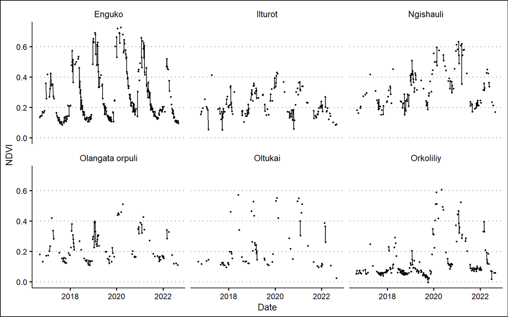

The raw time series contain noise and many missing values due to cloud cover and variable atmospheric conditions. We can fill these gaps using an intelligent smoothing approach to create a smooth time series that approximates the true time series values (based on Chen et al. 2004). The method relies on two facts: (a) Real NDVI tends to change smoothly, without abrupt spikes or drops. (b) Cloud cover and other disturbances tend to reduce NDVI values.

This means that we can make a best guess of the “true” value by fitting a curve to the upper envelope of the time series. To do this we use a Savitzky-Golay filter, which smooths out the jagged noise in the time series, and use it to boost unusually low values in the time series towards the upper envelope.

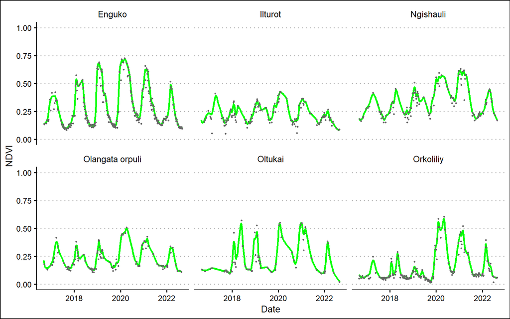

The grey shows the original data, while the green shows the smoothed version. It isn’t perfect - it still tends to give a spiky pattern when there is a lot of noise or not much data (e.g., in Orkoliliy) - but it is a big improvement on the original data. I am continuing to refine this.

The annual seasonal cycle is very clearly visible, and you can clearly see the differences between sites like Enguko and those like Orkoliliy. The smoother also preserves the overall shape of the increase at the start of each wet season and the subsequent decrease.

# Extracting vegetation metrics from satellite data

From these curves, we can start to extract some potentially useful metrics to track land health, degradation and resilience. A few we might be interested in are:

1. The peak greenness each year compared to baseline.
2. The overall area below the curve, a proxy for productivity.
3. The relationship between these values and rainfall.

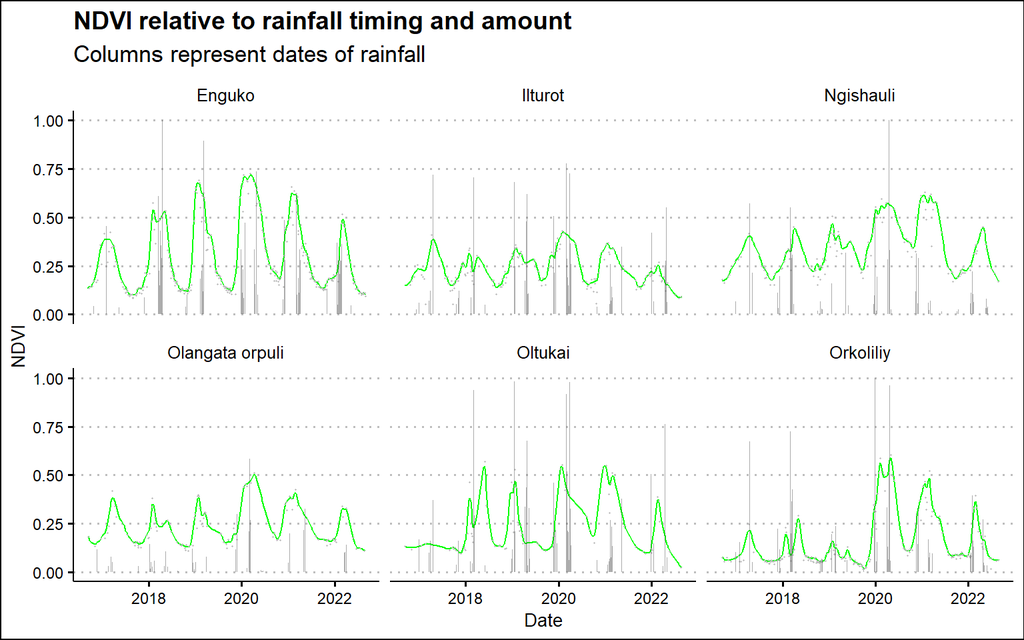

Another indicator of interest may be the recovery rate and decay rate of NDVI at the start or end of the season. More rapid recovery and greater persistence of green vegetation in the dry season may be associated with greater vegetation resilience and the presence of perennial grasses and herbs in addition to annual species.

We can quantify this for each site by fitting growth and decay curves to the NDVI profile for each year.

In the section below, the first figure shows an example of models fitted to the growth phase (start of the growing season) and the decay phase (end of the growing season). In some cases, the model hasn’t been able to fit the shape of the curve, because the shape is irregular.

Fitting these statistical models to the data allows us to extract the growth rate and decay rate of each season as a single number. We can then use these growth rates to explore how plots are changing over time, and examine whether this is driven by rainfall or other factors (like change in vegetation). The second figure shows the distribution of growth rates and decay rates for all the plots over the period 2017-2022.

```
#> Fitting time - growth:  27.446
```

```
#> Fitting time - decay:  56.92196
```

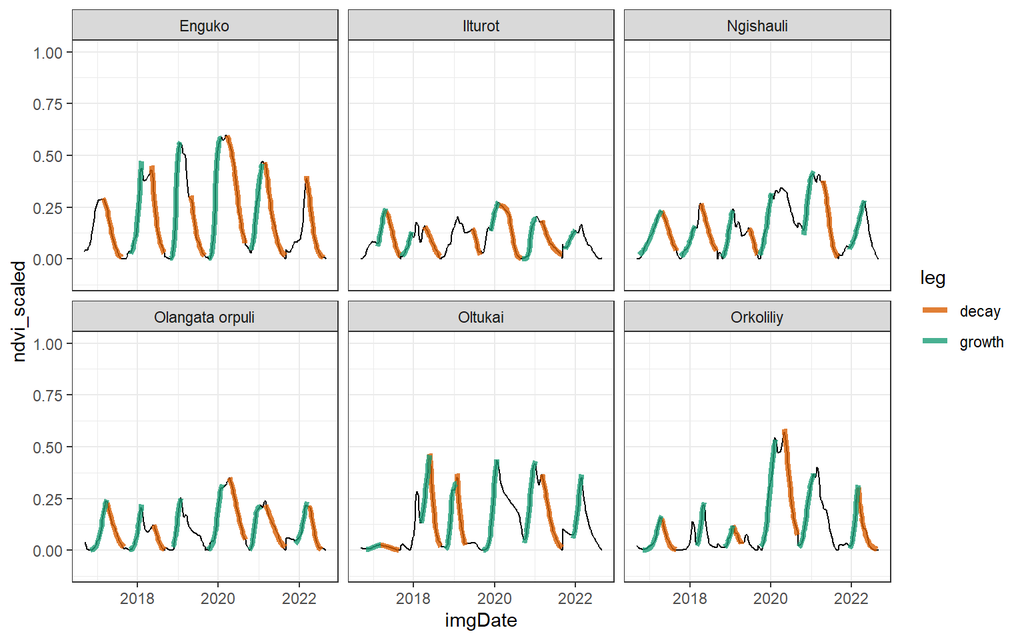

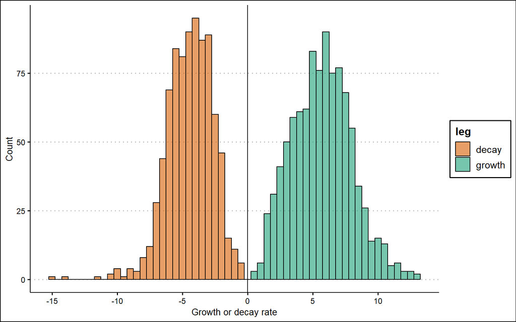

From here, we could use these data in different ways:

1. We could look at changes over time in greenness, in recovery/decay rates or in other metrics like rain use efficiency, to explore which plots or areas are improving or deteriorating over time.
2. We could examine the drivers behind the differences in growth or decay rates, for example distinguishing the effects of rainfall, soil type or management.
3. We could compare these metrics between regions with similar areas outside the regions that TPW works in, for example to better understand impact.
4. We could compare some of these metrics to the field data TPW has collected, for example in order to test whether they allow us to predict ground cover or the presence of particular species.